# Capstone Project, Elements of AI 2026

Anna Pylypenko, Kirill Putiatin

2026-05-01

# The Quest

The dataset we’ve chosen for this project is [Stack Overflow’s Developer Survey 2025](https://survey.stackoverflow.co/2025/). This dataset contains a lot of interesting questions about the developers occupation, tools, technologies, and opinions. The task we’ve chosen for this dataset is predicting a given developer’s yearly income using the questions in the survey.

The dataset contains over 150 variables and 49 000 rows. Unfortunately, a lot of those data points are either mostly unrelated noise or missing values, so this number will drop drastically as we get closer to fitting the models. It is a quite messy dataset with a lot of cleaning to do, so let’s start by loading the data.

# Data Cleaning and EDA

The dataset contains two CSV files: schema and data itself. Schema is a handy list of the majority of quesions, providing available answer options to them. When we discuss the questions closer, this table will be very useful for reference. The second file is the one we’re looking for, let’s confirm that it’s indeed loaded

```r
schema <- read_csv("data/survey_results_schema.csv", show_col_types = FALSE)
data <- read_csv("data/survey_results_public.csv", show_col_types = FALSE)
cat("Rows:", nrow(data), ", Cols:", ncol(data), "\n")
```

```
## Rows: 49191 , Cols: 172
```

```r
data %>% head(5)
```

```
## # A tibble: 5 × 172
##   ResponseId MainBranch          Age   EdLevel Employment EmploymentAddl WorkExp
##        <dbl> <chr>               <chr> <chr>   <chr>      <chr>            <dbl>
## 1          1 I am a developer b… 25-3… Master… Employed   Caring for de…       8
## 2          2 I am a developer b… 25-3… Associ… Employed   <NA>                 2
## 3          3 I am a developer b… 35-4… Bachel… Independe… None of the a…      10
## 4          4 I am a developer b… 35-4… Bachel… Employed   None of the a…       4
## 5          5 I am a developer b… 35-4… Master… Independe… Caring for de…      21
## # ℹ 165 more variables: LearnCodeChoose <chr>, LearnCode <chr>,
## #   LearnCodeAI <chr>, AILearnHow <chr>, YearsCode <dbl>, DevType <chr>,
## #   OrgSize <chr>, ICorPM <chr>, RemoteWork <chr>, PurchaseInfluence <chr>,
## #   TechEndorseIntro <chr>, TechEndorse_1 <dbl>, TechEndorse_2 <dbl>,
## #   TechEndorse_3 <dbl>, TechEndorse_4 <dbl>, TechEndorse_5 <dbl>,
## #   TechEndorse_6 <dbl>, TechEndorse_7 <dbl>, TechEndorse_8 <dbl>,
## #   TechEndorse_9 <dbl>, TechEndorse_13 <dbl>, TechEndorse_13_TEXT <chr>, …
```

First, let’s see what variables we’re working with

```r
data %>%
  summarise(across(everything(), list(
    class = ~ class(.x)[1],
    missing = ~ sum(is.na(.x) | .x == ""),
    n_unique = ~ n_distinct(.x, na.rm = TRUE),
    n = ~ sum(!is.na(.x) & .x != ""),
    variance = ~ var(.x, na.rm = TRUE)
  ))) %>%
  pivot_longer(
    everything(),
    names_to = c("variable", ".value"),
    names_pattern = "(.*)_(class|missing|n_unique|n|variance)"
  )
```

```
## # A tibble: 172 × 6
##    variable        class     missing n_unique     n   variance
##    <chr>           <chr>       <int>    <int> <int>      <dbl>
##  1 ResponseId      numeric         0    49191 49191 201650306
##  2 MainBranch      character       0        6 49191        NA
##  3 Age             character       0        7 49191        NA
##  4 EdLevel         character    1042        8 48149        NA
##  5 Employment      character     852        6 48339        NA
##  6 EmploymentAddl  character    4316      171 44875        NA
##  7 WorkExp         numeric      6298       72 42893       117.
##  8 LearnCodeChoose character    2333        3 46858        NA
##  9 LearnCode       character   15635     2767 33556        NA
## 10 LearnCodeAI     character    3990        5 45201        NA
## # ℹ 162 more rows
```

```r
data <- data %>%
  drop_na(ConvertedCompYearly) %>%
  filter(ConvertedCompYearly > 0) %>%
  filter(DevType != 'Student',
         DevType != 'Retired',
         DevType != 'Other (please specify):' ) %>%
  filter(Employment != 'Retired',
         Employment != 'Not employed',
         Employment != 'I prefer not to say' )
```

## Columns overview

```r
nominal_columns <- c("MainBranch", "EdLevel", "Employment",
                     "DevType", "ICorPM", "RemoteWork",
                     "Industry", "Country")
ordinal_columns <- c("Age", "OrgSize", "AIThreat", "SOAccount", "SOVisitFreq",
                     "SODuration",
                     "AISelect", "AISent", "AIAcc", "AIComplex", "AIAgents","AIAgentChange",
                     "JobSat")
numeric_columns <- c("WorkExp", "YearsCode", "ToolCountWork")

tech_usage_column_prefixes <- c("LanguageHaveWorkedWith", "DatabaseHaveWorkedWith", "PlatformHaveWorkedWith",
                                "WebframeHaveWorkedWith",  "DevEnvsHaveWorkedWith", "AIModelsHaveWorkedWith",
                                "CommPlatformHaveWorkedWith", "OfficeStackAsyncHaveWorkedWith", "OpSysProfessional use")

selected_features <- c(nominal_columns, ordinal_columns, numeric_columns,tech_usage_column_prefixes,"ConvertedCompYearly")

data_filtered <- data %>%
  select(all_of(selected_features))

cat("Rows:", nrow(data_filtered), ", Cols:", ncol(data_filtered), "\n")
```

```
## Rows: 22102 , Cols: 34
```

We see that our dataset have mostly character columns and only 5 numeric

```r
table(sapply(data_filtered, class))
```

```
##
## character   numeric
##        29         5
```

Next, we inspect the distributions of the variables. We’re using histogram and violin plots for that to better understand what kind of distributions we have. We save those plots to disk for easy inspection. This part is excluded from the documentation, but you can find it in the Rscript file.

## Predicted variable

Let’s inspect the predicted variable - ConvertedCompYearly. Most of the developers entered their income in local currency, so this variable is a cleaner version of the CompTotal variable. Here are some basic metrics:

```r
summary(data_filtered$ConvertedCompYearly)
```

```
##     Min.  1st Qu.   Median     Mean  3rd Qu.     Max.
##        1    41097    76570   103568   122753 50000000
```

And a histogram to better understand the distribution as well.

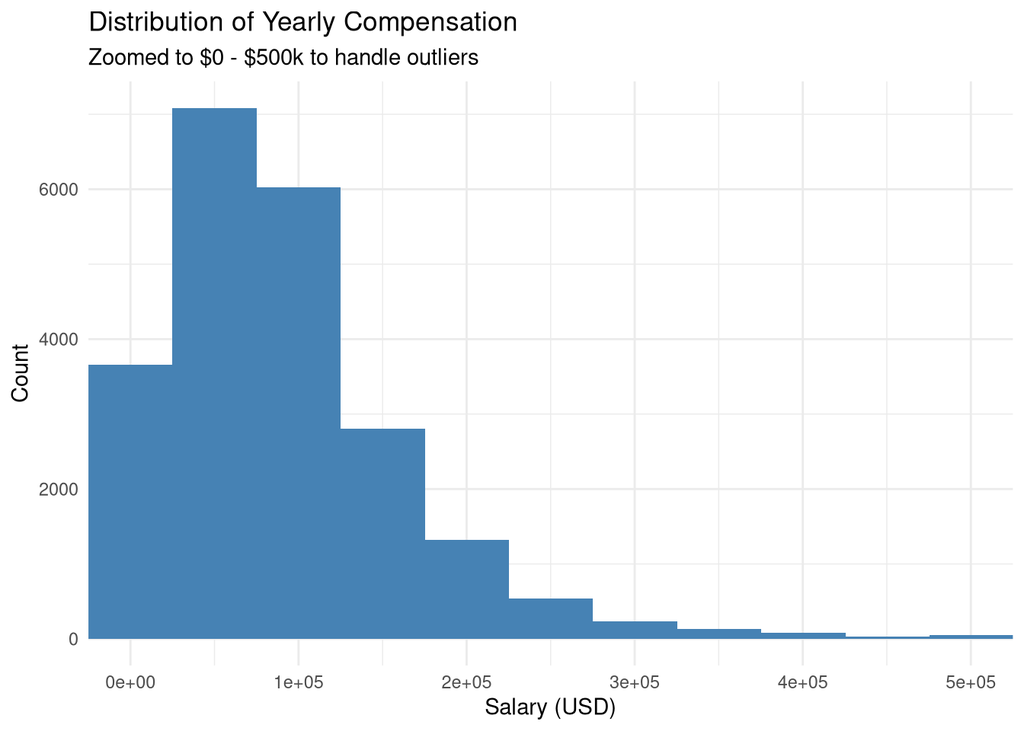

As we can see, there are a lot of outliers that are skewing the plot. Let’s select cutoff points to remove them.

```r
lower_bound <- quantile(data_filtered$ConvertedCompYearly, 0.025, na.rm = TRUE)
upper_bound <- quantile(data_filtered$ConvertedCompYearly, 0.975, na.rm = TRUE)
data_cleaned <- data_filtered %>%
  filter(ConvertedCompYearly >= lower_bound & ConvertedCompYearly <= upper_bound)
lower_bound; upper_bound
```

```
## 2.5%
##  999
```

```
## 97.5%
## 3e+05
```

Let’s see the distributions of yearly compensations in relation to employment status and country. We have to cut the outliers first, as there are quite a few of them, and group the countries into a factor of 20, so that they don’t blow out the plot. These distributions tell us that the ConvertedCompYearly is heavily dependent on the country, which can be helpful for modeling later

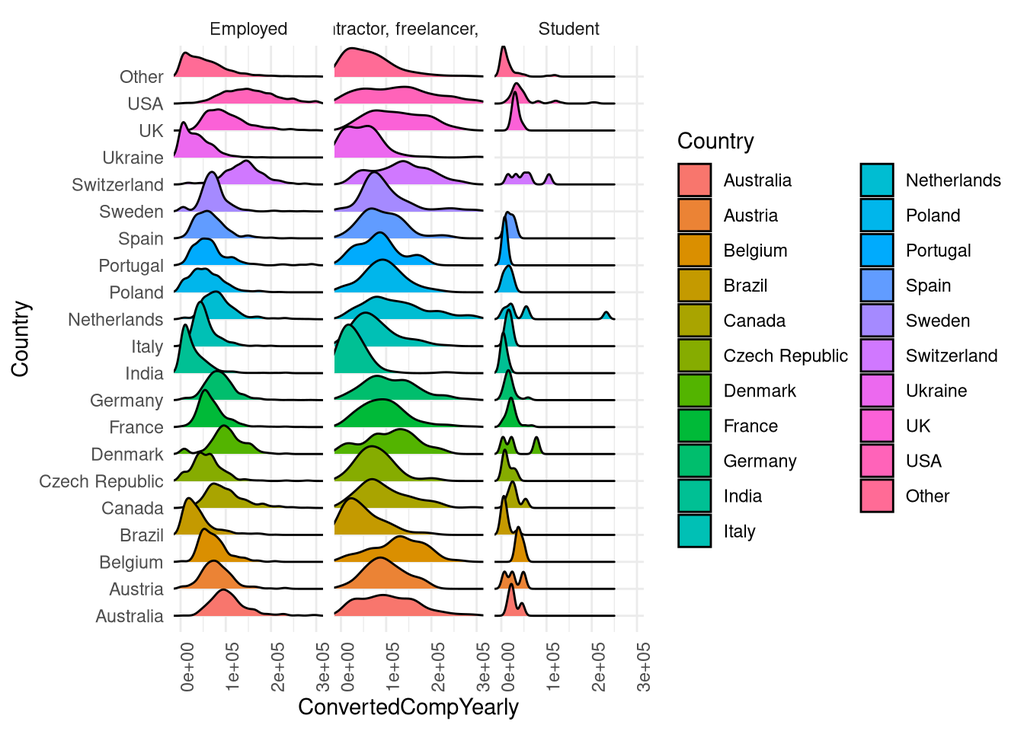

## Clean outliers in numeric values

We see unusually large number of tools and years of code and WorkExp. We should eliminate those outliers

```r
summary(data_cleaned$WorkExp)
```

```
##    Min. 1st Qu.  Median    Mean 3rd Qu.    Max.    NA's
##    1.00    6.00   11.00   13.55   20.00  100.00     218
```

```r
summary(data_cleaned$YearsCode)
```

```
##    Min. 1st Qu.  Median    Mean 3rd Qu.    Max.    NA's
##     1.0    10.0    15.0    17.8    25.0   100.0      71
```

```r
summary(data_cleaned$ToolCountWork)
```

```
##     Min.  1st Qu.   Median     Mean  3rd Qu.     Max.     NA's
##     0.00     4.00     6.00    13.25    10.00 10000.00     3038
```

```r
upper_bound_w <- quantile(data_filtered$WorkExp, 0.99, na.rm = TRUE)
upper_bound_w
```

```
## 99%
##  41
```

```r
upper_bound_y <- quantile(data_filtered$YearsCode, 0.99, na.rm = TRUE)
upper_bound_y
```

```
## 99%
##  45
```

```r
upper_bound_t <- quantile(data_filtered$ToolCountWork, 0.98, na.rm = TRUE)
upper_bound_t
```

```
## 98%
##  30
```

```r
data_cleaned <- data_cleaned %>%
  mutate(
    WorkExp = if_else(WorkExp > upper_bound_w, upper_bound_w, WorkExp),
    YearsCode = if_else(YearsCode > upper_bound_y, upper_bound_y, YearsCode),
    ToolCountWork = if_else(ToolCountWork > upper_bound_t, upper_bound_t, ToolCountWork)
  )
```

This is the resulting data after pre-processing

```r
cat("Rows:", nrow(data_cleaned), ", Cols:", ncol(data_cleaned), "\n")
```

```
## Rows: 21049 , Cols: 34
```

## Initial recipe

Let’s start a recipe. We’ll start by assigning roles to our variables, which will help us to handle them later

```r
roles_recipe <- recipe(
    data = data_cleaned,
    formula = ConvertedCompYearly ~ .
) %>%
    add_role(all_of(nominal_columns), new_role = "nominal") %>%
    add_role(all_of(ordinal_columns), new_role = "ordinal") %>%
    add_role(all_of(numeric_columns), new_role = "numeric") %>%
    add_role(starts_with(tech_usage_column_prefixes), new_role = "tech")
```

## Nominal variables

MainBranch and Age are the only variables without missing values. One-by-one, let’s handle missing values. For some of them, NA means an empty answer, not applicable, or “I prefer not to say”. For some of them, we can fill NA with the mode.

ICorPM is transformed into a IsPM variable. ICorPM has only 2 options: “People manager” and “Individual contributor”. The rest of the options are NA, with the mode being the contributor. It doesn’t make much sense to add another value to the variable, so we can effectively convert this variable to a binary one. This could be potentially useful information, judging by the domain.

DevType doesn’t have an additional free-text variable to work with, so it is logical to group the “Other” option with the “Prefer not to say” (missing) values.

EdLevel is imputed with the least possible value. This variable could derive an ordinal feature that indicated the highest education level, but it would lose the information about the field of study in higher education. Another feature could be engineered, indicating the presence of a *higher* education.

“Country” is a high-cardinal variable, meaning we have to eventually eliminate most of its options. There are many ways to do that, but most of them fail using the recipes. The recipes are prepared for train and test data separately, so the resulting columns may not coincide if the distribution of the countries differs even slightly. We ran into the issue when we tried to put an “Other” category of all countries that had less than 1% of the sample, but the countries that we were left with in train and test data were different. This is why the country factor is hard-coded, although it originates from that distribution (on training data).

The rest of the variables are imputed with new “Missing” values, then their distinct options are renamed to better fit the encoding.

Get all distinct values of a column, then print it into console in a format to be inserted into fct_recode(). Helpful for quick option renaming

```
## ── Recipe ──────────────────────────────────────────────────────────────────────
```

```
## ── Inputs
```

```
## Number of variables by role
```

```
## outcome:    1
## predictor: 33
## ordinal:   13
## tech:       9
## nominal:    8
## numeric:    3
```

```
## ── Operations
```

```
## • Character variables from: has_role("nominal")
```

```
## • Mode imputation for: ICorPM RemoteWork
```

```
## • Variable mutation for: replace_na(EdLevel, "Primary/elementary school")
```

```
## • Unknown factor level assignment for: Industry
```

```
## • Variable mutation for: fct_recode(MainBranch, Developer = "I am a developer
##   by profession", Student = "I am learning to code", Occasional = "I am not
##   primarily a developer, but I write code sometimes as part of my
##   work/studies", Hobbyist = "I code primarily as a hobby", ExDeveloper = "I
##   used to be a developer by profession, but no longer am", Adjacent = "I work
##   with developers or my work supports developers but am not a developer by
##   profession"), fct_recode(EdLevel, Associate = "Associate degree (A.A., A.S.,
##   etc.)", Bachelor = "Bachelor’s degree (B.A., B.S., B.Eng., etc.)", Master =
##   "Master’s degree (M.A., M.S., M.Eng., MBA, etc.)", Other = "Other (please
##   specify):", Primary = "Primary/elementary school", Professional =
##   "Professional degree (JD, MD, Ph.D, Ed.D, etc.)", Secondary = "Secondary
##   school (e.g. American high school, German Realschule or Gymnasium, etc.)",
##   Dropout = "Some college/university study without earning a degree", ),
##   fct_recode(Employment, Independent = "Independent contractor, freelancer, or
##   self-employed", ), fct_recode(DevType, Academic = "Academic researcher",
##   MLEngineer = "AI/ML engineer", Scientist = "Applied scientist", Architect =
##   "Architect, software or solutions", CloudEngineer = "Cloud infrastructure
##   engineer", Cybersecurity = "Cybersecurity or InfoSec professional",
##   DataEngineer = "Data engineer", BusinessAnalyst = "Data or business analyst",
##   DataScientist = "Data scientist", DatabaseAdmin = "Database administrator or
##   engineer", AIDeveloper = "Developer, AI apps or physical AI", Backend =
##   "Developer, back-end", Desktop = "Developer, desktop or enterprise
##   applications", Embedded = "Developer, embedded applications or devices",
##   Frontend = "Developer, front-end", Fullstack = "Developer, full-stack", Game
##   = "Developer, game or graphics", Mobile = "Developer, mobile", QA =
##   "Developer, QA or test", DevOps = "DevOps engineer or professional",
##   EngineeringManager = "Engineering manager", FinancialAnalyst = "Financial
##   analyst or engineer", Founder = "Founder, technology or otherwise",
##   ProductManager = "Product manager", ProjectManager = "Project manager",
##   Executive = "Senior executive (C-suite, VP, etc.)", Support = "Support
##   engineer or analyst", SysAdmin = "System administrator", Designer = "UX,
##   Research Ops or UI design professional", ), fct_recode(RemoteWork, Hybrid =
##   "Hybrid (some in-person, leans heavy to flexibility)", Hybrid = "Hybrid (some
##   remote, leans heavy to in-person)", InPerson = "In-person", Remote =
##   "Remote", Flexible = "Your choice (very flexible, you can come in when you
##   want or just as needed)", )
```

```
## • Variable renaming for: IsPM
```

```
## • Variable mutation for: if_else(IsPM == "People manager", 1L, 0L)
```

```
## • Variable mutation for: factor(if_else(as.character(Country) %in%
##   country_list, Country, "Other"), levels = c(country_list, "Other"))
```

## Ordinal variables

Ordinal variables require a set order, so we create the order from their meaning. There are a lot of missing values here, but in most cases we can handle them by inserting an appropriate level instead of the mode. A lot of the variables include the “Prefer not to say” option, so we can assume that the person who have left the field unmarked for any reason was meaning to select precisely that option.

```
## ── Recipe ──────────────────────────────────────────────────────────────────────
```

```
## ── Inputs
```

```
## Number of variables by role
```

```
## outcome:    1
## predictor: 33
## ordinal:   13
## tech:       9
## nominal:    8
## numeric:    3
```

```
## ── Operations
```

```
## • Character variables from: has_role("nominal")
```

```
## • Mode imputation for: ICorPM RemoteWork
```

```
## • Variable mutation for: replace_na(EdLevel, "Primary/elementary school")
```

```
## • Unknown factor level assignment for: Industry
```

```
## • Variable mutation for: fct_recode(MainBranch, Developer = "I am a developer
##   by profession", Student = "I am learning to code", Occasional = "I am not
##   primarily a developer, but I write code sometimes as part of my
##   work/studies", Hobbyist = "I code primarily as a hobby", ExDeveloper = "I
##   used to be a developer by profession, but no longer am", Adjacent = "I work
##   with developers or my work supports developers but am not a developer by
##   profession"), fct_recode(EdLevel, Associate = "Associate degree (A.A., A.S.,
##   etc.)", Bachelor = "Bachelor’s degree (B.A., B.S., B.Eng., etc.)", Master =
##   "Master’s degree (M.A., M.S., M.Eng., MBA, etc.)", Other = "Other (please
##   specify):", Primary = "Primary/elementary school", Professional =
##   "Professional degree (JD, MD, Ph.D, Ed.D, etc.)", Secondary = "Secondary
##   school (e.g. American high school, German Realschule or Gymnasium, etc.)",
##   Dropout = "Some college/university study without earning a degree", ),
##   fct_recode(Employment, Independent = "Independent contractor, freelancer, or
##   self-employed", ), fct_recode(DevType, Academic = "Academic researcher",
##   MLEngineer = "AI/ML engineer", Scientist = "Applied scientist", Architect =
##   "Architect, software or solutions", CloudEngineer = "Cloud infrastructure
##   engineer", Cybersecurity = "Cybersecurity or InfoSec professional",
##   DataEngineer = "Data engineer", BusinessAnalyst = "Data or business analyst",
##   DataScientist = "Data scientist", DatabaseAdmin = "Database administrator or
##   engineer", AIDeveloper = "Developer, AI apps or physical AI", Backend =
##   "Developer, back-end", Desktop = "Developer, desktop or enterprise
##   applications", Embedded = "Developer, embedded applications or devices",
##   Frontend = "Developer, front-end", Fullstack = "Developer, full-stack", Game
##   = "Developer, game or graphics", Mobile = "Developer, mobile", QA =
##   "Developer, QA or test", DevOps = "DevOps engineer or professional",
##   EngineeringManager = "Engineering manager", FinancialAnalyst = "Financial
##   analyst or engineer", Founder = "Founder, technology or otherwise",
##   ProductManager = "Product manager", ProjectManager = "Project manager",
##   Executive = "Senior executive (C-suite, VP, etc.)", Support = "Support
##   engineer or analyst", SysAdmin = "System administrator", Designer = "UX,
##   Research Ops or UI design professional", ), fct_recode(RemoteWork, Hybrid =
##   "Hybrid (some in-person, leans heavy to flexibility)", Hybrid = "Hybrid (some
##   remote, leans heavy to in-person)", InPerson = "In-person", Remote =
##   "Remote", Flexible = "Your choice (very flexible, you can come in when you
##   want or just as needed)", )
```

```
## • Variable renaming for: IsPM
```

```
## • Variable mutation for: if_else(IsPM == "People manager", 1L, 0L)
```

```
## • Variable mutation for: factor(if_else(as.character(Country) %in%
##   country_list, Country, "Other"), levels = c(country_list, "Other"))
```

```
## • Variable mutation for: Age %>% factor(levels = c("Prefer not to say", "18-24
##   years old", "25-34 years old", "35-44 years old", "45-54 years old", "55-64
##   years old", "65 years or older"), ordered = TRUE)
```

```
## • Variable mutation for: OrgSize %>% factor(levels = c("None", "Just me - I am
##   a freelancer, sole proprietor, etc.", "Less than 20 employees", "20 to 99
##   employees", "100 to 499 employees", "500 to 999 employees", "1,000 to 4,999
##   employees", "5,000 to 9,999 employees", "10,000 or more employees", "I don't
##   know"), ordered = TRUE) %>% fct_recode(None = "I don't know") %>%
##   fct_na_value_to_level("None")
```

```
## • Variable mutation for: AIThreat %>% factor(ordered = TRUE, levels = c("No",
##   "I'm not sure", "Yes")) %>% fct_recode(No = "I'm not sure") %>%
##   fct_na_value_to_level("No") %>% fct_relevel(c("No", "Yes"))
```

```
## • Variable mutation for: SOAccount %>% factor(levels = c("No", "Not sure/can't
##   remember", "Yes"), ordered = TRUE) %>% fct_na_value_to_level("Not sure/can't
##   remember")
```

```
## • Variable mutation for: SOVisitFreq %>% factor(ordered = TRUE, levels =
##   c("Infrequently, less than once per year", "Less than once every 2 - 3
##   months", "Less than once per month or monthly", "A few times per month or
##   weekly", "A few times per week", "Daily or almost daily", "Multiple times per
##   day")) %>% fct_na_value_to_level("Infrequently, less than once per year")
```

```
## • Variable mutation for: SODuration %>% factor(ordered = TRUE, levels = c("I
##   don't use Stack Overflow", "Less than one year", "Between 1 and 3 years",
##   "Between 3 and 5 years", "Between 5 and 10 years", "Between 10 and 15 years",
##   "More than 15 years, or since Stack Overflow started in 2008")) %>%
##   fct_na_value_to_level("I don't use Stack Overflow")
```

```
## • Variable mutation for: AISelect %>% factor(ordered = TRUE, levels = c("No,
##   and I don't plan to", "No, but I plan to soon", "Yes, I use AI tools monthly
##   or infrequently", "Yes, I use AI tools weekly", "Yes, I use AI tools daily"))
##   %>% fct_na_value_to_level("Yes, I use AI tools monthly or infrequently")
```

```
## • Variable mutation for: AISent %>% factor(ordered = TRUE, levels = c("Very
##   unfavorable", "Unfavorable", "Unsure", "Indifferent", "Favorable", "Very
##   favorable")) %>% fct_na_value_to_level("Indifferent")
```

```
## • Variable mutation for: AIAcc %>% factor(ordered = TRUE, levels = c("Highly
##   distrust", "Highly trust", "Neither trust nor distrust", "Somewhat distrust",
##   "Somewhat trust")) %>% fct_na_value_to_level("Neither trust nor distrust")
```

```
## • Variable mutation for: AIComplex %>% factor(ordered = TRUE, levels = c("Very
##   poor at handling complex tasks", "Bad at handling complex tasks", "I don't
##   use AI tools for complex tasks / I don't know", "Neither good or bad at
##   handling complex tasks", "Good, but not great at handling complex tasks",
##   "Very well at handling complex tasks")) %>% fct_na_value_to_level("I don't
##   use AI tools for complex tasks / I don't know")
```

```
## • Variable mutation for: AIAgents %>% factor(ordered = TRUE, levels = c("No,
##   and I don't plan to", "No, but I plan to", "No, I use AI exclusively in
##   copilot/autocomplete mode", "Yes, I use AI agents at work daily", "Yes, I use
##   AI agents at work monthly or infrequently", "Yes, I use AI agents at work
##   weekly")) %>% fct_na_value_to_level("No, and I don't plan to")
```

```
## • Variable mutation for: AIAgentChange %>% factor(ordered = TRUE, levels =
##   c("Not at all or minimally", "No, but my development work has changed
##   somewhat due to non-AI factors", "No, but my development work has
##   significantly changed due to non-AI factors", "Yes, somewhat", "Yes, to a
##   great extent")) %>% fct_na_value_to_level("Not at all or minimally")
```

```
## • Median imputation for: JobSat
```

## Numeric variables

Numeric columns are simplest to replace with their medians, as we’ve already removed the outliers. There isn’t much cleaning to do beside that

```r
numeric_recipe <- ordinal_recipe %>%
    step_impute_median(has_role("numeric"))
```

## Final recipe

Let’s remove all unused variables from the final recipe. They are potentially meaningful, but since we have enough variables already (>20 before encoding), we won’t waste a lot of time trying to extract every single information point from likely marginally unrelated variables Encoding will be done on per-model basis, as different models will also require different preprocessing steps

```r
final_recipe <- numeric_recipe %>%
    step_rm(-has_role("numeric"), -has_role("ordinal"), -has_role("nominal"), -has_role("outcome"))
```

# Linear regression

First of all, let’s check the correlation between the variables. We don’t want collinear variables. Starting from ordinal and numeric variables, let’s build correlation matrices

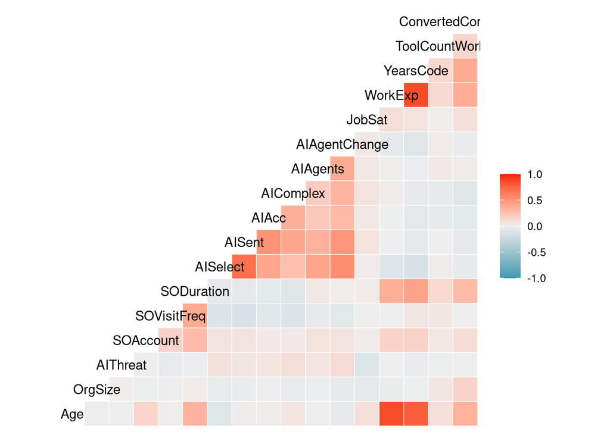

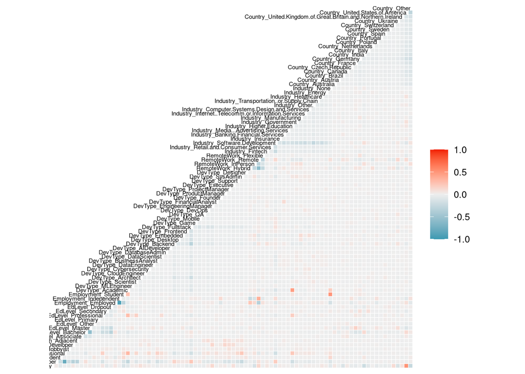

Let’s prepare our variables for fitting the linear regression model. We’ll use residual sum of squares, lm engine Removing previously mentioned variables to avoid multicollinearity.

We have tried normalizing the inputs, but it doesn’t make much difference since most of our features are on the scale of 0-1.

The H_0 in this case is that each of the selected features does not have any relation to the predicted outcome. After fitting the model, using the tidy() function we can study each predicted coefficient and its metrics, which suggested that for some of the predictors we fail to reject the H_0. We removed these features without changing the performance of the model.

```r
lr_recipe <- final_recipe %>%
    step_naomit(has_role("outcome")) %>%
    step_rm(-has_role("numeric"), -has_role("ordinal"), -has_role("nominal"), -has_role("outcome")) %>%
    step_rm(Age, YearsCode, starts_with("SO"), starts_with("AI")) %>%
    step_dummy(has_role("nominal"), one_hot = FALSE) %>%
    step_rm("Industry_Higher.Education", "MainBranch_Occasional") %>%
    step_rm("Country_United.Kingdom.of.Great.Britain.and.Northern.Ireland",
            "EdLevel_Other",
            "RemoteWork_Flexible",
            "Country_Canada",
            "DevType_BusinessAnalyst",
            "DevType_SysAdmin",
            "MainBranch_Adjacent",
            "Industry_None",
            "MainBranch_ExDeveloper",
            "Industry_Insurance",
            "DevType_Support",
            "Industry_Government",
            "EdLevel_Primary"
    ) %>%
    step_ordinalscore(has_role("ordinal"), -c("JobSat"))
```

Splitting data. Using a simple proportion of 80/20

```r
set.seed(142)
data_split <- initial_split(data_cleaned, prop = .8)
```

```r
lr_spec <- linear_reg(engine = "lm")
lr_metrics <- metric_set(rmse, mae, rsq)

workflow() %>%
    add_recipe(lr_recipe) %>%
    add_model(lr_spec) %>%
    last_fit(data_split, metrics = lr_metrics) -> lm_fit_result

lm_fit_result %>% extract_workflow() %>% tidy(conf.int = TRUE) %>%
    arrange(p.value)
```

```
## # A tibble: 68 × 7
##    term                estimate std.error statistic   p.value conf.low conf.high
##    <chr>                  <dbl>     <dbl>     <dbl>     <dbl>    <dbl>     <dbl>
##  1 Country_United.Sta…   47066.    1167.       40.3 0           44779.    49353.
##  2 WorkExp                1327.      38.4      34.6 3.03e-253    1252.     1403.
##  3 Country_India        -61591.    1810.      -34.0 1.67e-245  -65138.   -58043.
##  4 Country_Other        -34373.    1145.      -30.0 6.31e-193  -36617.   -32128.
##  5 Country_Ukraine      -61439.    2210.      -27.8 2.51e-166  -65771.   -57107.
##  6 Country_Brazil       -55684.    2232.      -25.0 5.68e-135  -60058.   -51310.
##  7 DevType_Engineerin…   52135.    2433.       21.4 1.56e-100   47366.    56904.
##  8 OrgSize                3503.     170.       20.6 5.66e- 93    3169.     3837.
##  9 DevType_Backend       31994.    1795.       17.8 2.10e- 70   28475.    35513.
## 10 DevType_Executive     59214.    3339.       17.7 9.48e- 70   52670.    65758.
## # ℹ 58 more rows
```

There are strong evidence that suggests we have to reject the H_0 for a number of features after fitting, considering the low p-values. The other metrics for the estimated coefficients are also strong, let’s see the metrics of the model.

```r
lm_fit_result %>% collect_metrics()
```

```
## # A tibble: 3 × 4
##   .metric .estimator .estimate .config
##   <chr>   <chr>          <dbl> <chr>
## 1 rmse    standard   42661.    pre0_mod0_post0
## 2 mae     standard   31316.    pre0_mod0_post0
## 3 rsq     standard       0.526 pre0_mod0_post0
```

R^2 is around 52%, RMSE is 42k and MAE is 31k. These are the best statistics we were able to achieve using linear regression using different data cleaning techniques. Let’s inspect scatter plot that shows us how the errors are distributed across true outcome values.

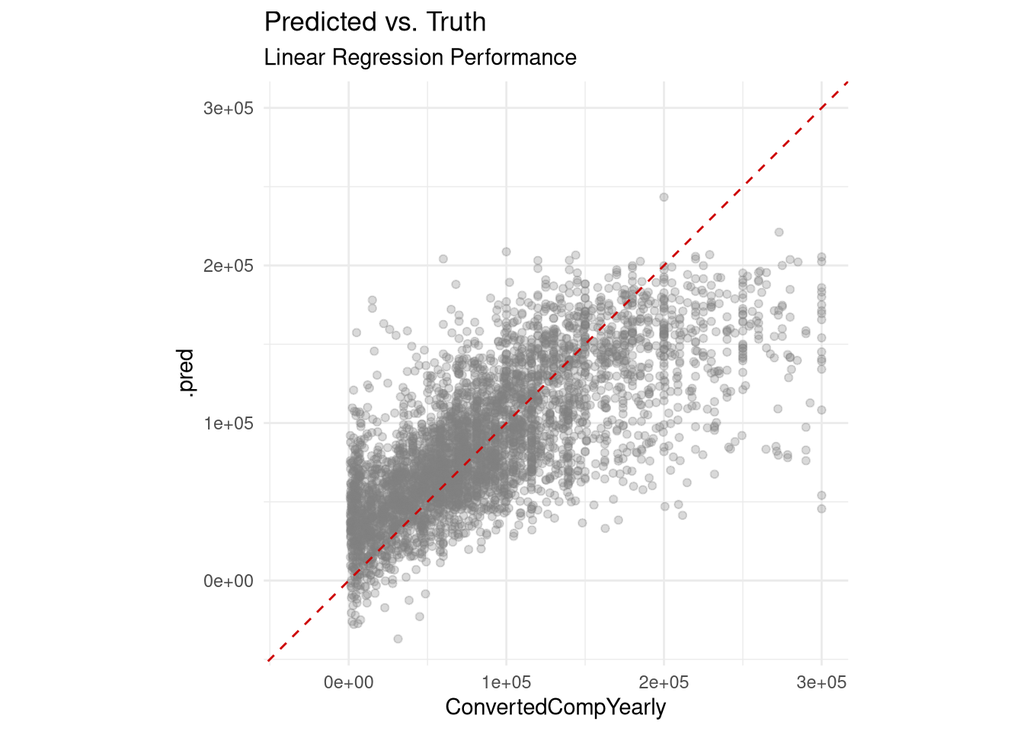

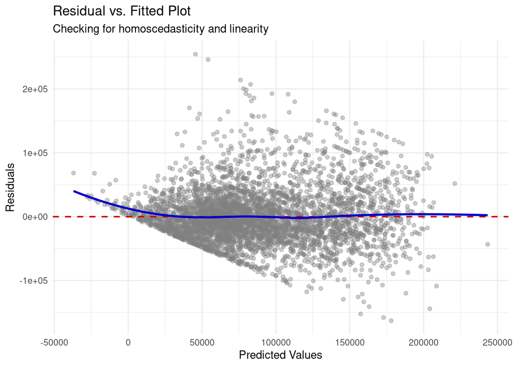

# Random forest

The next model we’ve chosen is random forest. We have a lot of rows to train on, a lot of variables and noise, so we’ll use random forest rather than a decision tree.

The random forest works better with categorical values than linear regression, since it doesn’t need them encoded in multiple values. Let’s prepare the recipe for our model fitting and evaluation.

```r
rf_recipe <- final_recipe %>%
    step_naomit(has_role("outcome")) %>%
    #step_log(all_outcomes()) %>%
    step_rm(-has_role("numeric"), -has_role("ordinal"), -has_role("nominal"), -has_role("outcome")) %>%
    #step_rm(Age, YearsCode, starts_with("SO"), starts_with("AI")) %>%
    #step_dummy(has_role("nominal"), one_hot = FALSE) %>%
    #step_rm("Industry_Higher.Education", "MainBranch_Occasional") %>%
    step_ordinalscore(has_role("ordinal"), -c("JobSat")) %>%
    step_integer(has_role("nominal"))
```

The best hyperparameters we can find are the following: 2000 trees, 10 random variables are selected (from ~25), minimum 2 data points in a node. We selected MSE, MAE, MAPE and RMSE as our metrics.

```r
rf_spec <- rand_forest(
    mode = "regression",
    engine = "ranger",
    trees = 2000,
    mtry = 10,
    min_n = 2)

rf_metrics <- metric_set(mse, mae, mape, rmse)

workflow() %>%
    add_recipe(rf_recipe) %>%
    add_model(rf_spec) %>%
    last_fit(data_split, metrics = rf_metrics) -> rf_fit_result

rf_fit_result %>%
    collect_metrics()
```

```
## # A tibble: 4 × 4
##   .metric .estimator   .estimate .config
##   <chr>   <chr>            <dbl> <chr>
## 1 mse     standard   1797814872. pre0_mod0_post0
## 2 mae     standard        31035. pre0_mod0_post0
## 3 mape    standard          148. pre0_mod0_post0
## 4 rmse    standard        42401. pre0_mod0_post0
```

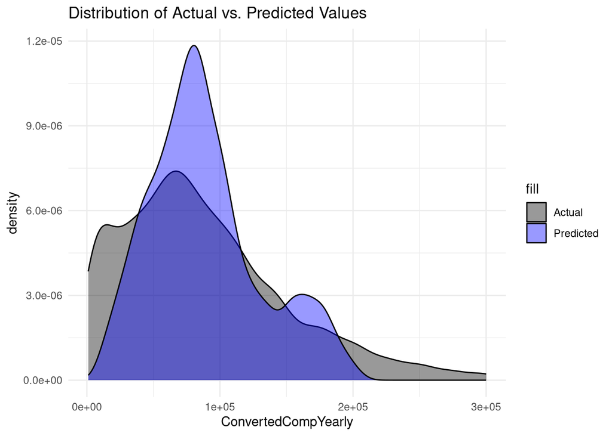

```r
rf_fit_result %>%
    collect_predictions() %>%
    ggplot() +
    geom_density(aes(x = ConvertedCompYearly, fill = "Actual"), alpha = 0.4) +
    geom_density(aes(x = .pred, fill = "Predicted"), alpha = 0.4) +
    scale_fill_manual(values = c("Actual" = "black", "Predicted" = "blue")) +
    theme_minimal() +
    labs(title = "Distribution of Actual vs. Predicted Values")
```